# Pràctica 9 ANS

Lucas Poveda

2023-06-13

PRACTICA 9

```r
library(fBasics)
```

#1. Preliminars ##1.1. Dades i Objectius OBJECTIUS: 1) Determinar si Les mesures f´ısiques dels cranis permeten discriminar/classificar la regi´o de proced`encia. 2) En cas afirmatiu, fer prediccions de les dades d’entrenament i de dades noves

```r
"Tibet" <-
structure(.Data = list(c(190.5, 172.5, 167., 169.5, 175., 177.5, 179.5, 179.5, 173.5, 162.5, 178.5, 171.5, 180.5, 183., 169.5, 172., 170.,
    182.5, 179.5, 191., 184.5, 181., 173.5, 188.5, 175., 196., 200., 185., 174.5, 195.5, 197., 182.5)
, c(152.5, 132., 130., 150.5, 138.5, 142.5, 142.5, 138., 135.5, 139., 135., 148.5, 139., 149., 130., 140., 126.5,
    136., 135., 140.5, 141.5, 142., 136.5, 130., 153., 142.5, 139.5, 134.5, 143.5, 144., 131.5, 131.)
, c(145., 125.5, 125.5, 133.5, 126., 142.5, 127.5, 133.5, 130.5, 131., 136., 132.5, 132., 121.5, 131., 136., 134.5,
    138.5, 128.5, 140.5, 134.5, 132.5, 126., 143., 130., 123.5, 143.5, 140., 132.5, 138.5, 135., 135.)
, c(73.5, 63., 69.5, 64.5, 77.5, 71.5, 70.5, 73.5, 70., 62., 71., 65., 74.5, 76.5, 68., 70.5, 66., 76., 74., 72.5,
    76.5, 79., 71.5, 79.5, 76.5, 76., 82.5, 81.5, 74., 78.5, 80.5, 68.5)
, c(136.5, 121., 119.5, 128., 135.5, 131., 134.5, 132.5, 133.5, 126., 124., 146.5, 134.5, 142., 119., 133.5, 118.5,
    134., 132., 131.5, 141.5, 136.5, 136.5, 136., 142., 134., 146., 137., 136.5, 144., 139., 136.)
, structure(.Data = c(1, 1, 1, 1, 1, 1, 1, 1, 1, 1, 1, 1, 1, 1, 1, 1, 1, 2, 2, 2, 2, 2, 2, 2, 2, 2, 2, 2, 2, 2, 2, 2)
, levels = c("1", "2")
, class = "factor"
)
)
, names = c("Length", "Breadth", "Height", "Fheight", "Fbreadth", "Type")
, row.names = c("1", "2", "3", "4", "5", "6", "7", "8", "9", "10", "11", "12", "13", "14", "15", "16", "17", "18", "19", "20",
    "21", "22", "23", "24", "25", "26", "27", "28", "29", "30", "31", "32")
, class = "data.frame"
)
```

```r
library(MASS)
head(Tibet); tail(Tibet)
```

```
##   Length Breadth Height Fheight Fbreadth Type
## 1  190.5   152.5  145.0    73.5    136.5    1
## 2  172.5   132.0  125.5    63.0    121.0    1
## 3  167.0   130.0  125.5    69.5    119.5    1
## 4  169.5   150.5  133.5    64.5    128.0    1
## 5  175.0   138.5  126.0    77.5    135.5    1
## 6  177.5   142.5  142.5    71.5    131.0    1
```

```
##    Length Breadth Height Fheight Fbreadth Type
## 27  200.0   139.5  143.5    82.5    146.0    2
## 28  185.0   134.5  140.0    81.5    137.0    2
## 29  174.5   143.5  132.5    74.0    136.5    2
## 30  195.5   144.0  138.5    78.5    144.0    2
## 31  197.0   131.5  135.0    80.5    139.0    2
## 32  182.5   131.0  135.0    68.5    136.0    2
```

```r
means <- by(Tibet[-6], Tibet$Type, function(x)apply(x,2,mean), simplify=T)
k <- 2
means <- as.list(means)
names(means) <- paste0("m",1:k)
list2env(means,globalenv())
```

```
## <environment: R_GlobalEnv>
```

##1.2. Test t^2 de Hotelling (nomes si k=2 grups)

 Primer, calcula la pooled covariance matrix, S  Seguidament, calcula un valor reescalat de la dist`ancia D2 de Mahalanobis al quadrat entre els dos centroides(mostrals) i el valor de l’estad´ıstic T^2  Sota la hip`otesi nul·la t´e llei de Fisher-Snedecor amb ν1 = p i ν2 = n1 + n2 − p − 1 graus de llibertat. Calcula elvalor de l’estad´ıstic de contrast i el p-valor.

2 opciones: - Codigo con R

```r
sizes <- by(Tibet, Tibet$Type, function(x)nrow(x), simplify=T)
sizes <- as.list(sizes)
names(sizes) <- paste0("n",1:k)
list2env(sizes,globalenv())
```

```
## <environment: R_GlobalEnv>
```

```r
n <- n1+n2 # ; n <- nrow(Tibet) # idem
p <- ncol(Tibet[-6])
covs <- by(Tibet[-6], Tibet$Type, function(x)cov(x), simplify=T)
covs <- as.list(covs)
names(covs) <- paste0("S",1:k)
list2env(covs,globalenv())
```

```
## <environment: R_GlobalEnv>
```

```r
#1 Primer, calcula la pooled covariance matrix, S
Spool <- ((n1-1)*S1 +(n2-1)*S2)/(n-2)
# C`alcul alternatiu, amb mapply() i Reduce(), operant amb llistes de matrius
# sizes.cor <- mapply("-", sizes, 1, SIMPLIFY=FALSE) # ni -1 # mides corregides
# aux <- mapply("*", sizes.cor, covs, SIMPLIFY=FALSE) # multipl: (ni-1)*Si
# Saux <- Reduce('+',aux)/(n-2) # !! Opera dins de aux


#Seguidament, calcula un valor reescalat de la dist`ancia D2 de Mahalanobis al quadrat entre els dos centroides(mostrals) i el valor de l’estad´ıstic T^2
D2 <- matrix(m1-m2,nrow=1) %*% solve(Spool) %*% matrix(m1-m2,ncol=1)
T2<- D2*(n1*n2)/(n1+n2)


# Sota la hip`otesi nul·la t´e llei de Fisher-Snedecor amb ν1 = p i ν2 = n1 + n2 − p − 1 graus de llibertat. Calcula elvalor de l’estad´ıstic de contrast i el p-valor.
Fobs<-(n1+n2-p-1)*T2/(p*(n1+n2-2))
pval<-1-pf(Fobs,p,n1+n2-p-1); pval
```

```
##             [,1]
## [1,] 0.002936228
```

- Otra opción con un paquete específico para la funcion

```r
#library(Hotelling)
#fit<-hotelling.test(.~Type, data=Tibet)
#fit; # names(fit)
```

#2 Discriminant lineal per a k = 2 grups amb lda()

```r
dis<-lda(Type~.,data=Tibet,prior=c(0.5,0.5)) # priors iguals # altres opcions: freq mostral dels grups, ...
dis; names(dis)
```

```
## Call:
## lda(Type ~ ., data = Tibet, prior = c(0.5, 0.5))
##
## Prior probabilities of groups:
##   1   2
## 0.5 0.5
##
## Group means:
##     Length  Breadth   Height  Fheight Fbreadth
## 1 174.8235 139.3529 132.0000 69.82353 130.3529
## 2 185.7333 138.7333 134.7667 76.46667 137.5000
##
## Coefficients of linear discriminants:
##                   LD1
## Length    0.047726591
## Breadth  -0.083247929
## Height   -0.002795841
## Fheight   0.094695000
## Fbreadth  0.094809401
```

```
##  [1] "prior"   "counts"  "means"   "scaling" "lev"     "svd"     "N"
##  [8] "call"    "terms"   "xlevels"
```

##2.1. Prediccions amb predict()

```r
names(predict(dis))
```

```
## [1] "class"     "posterior" "x"
```

- $class ´es el grup predit Gp.
- $posterior son les probabilitats a posteriori de pertinenca als k = 2 grups.
- $x son les puntuacions discriminants centrades (scores) d(x) dels individus

1.Un criteri de predicci´o ´es: m`axima probabilitat a posteriori de pertanyer al grup. L’altre ´es: m´ınima dist`ancia de d(x) a la projecci´o del centroide di.

2.Analitzem el comportament predictiu validant amb les mateixes dades usades per obtenir la funci´o discriminant

```r
#1
grup.pr <- predict(dis)$class
resum <- cbind(predict(dis)$posterior,predict(dis)$x,predict(dis)$class)
colnames(resum) <- c ("post1","post2","dx","G.pred")
head(resum,3)
```

```
##       post1      post2         dx G.pred
## 1 0.6736423 0.32635771 -0.3872915      1
## 2 0.9745982 0.02540180 -1.9491119      1
## 3 0.9498455 0.05015452 -1.5718089      1
```

```r
#2
tab<-table(real=Tibet$Type,pred=grup.pr)
tab.f<-prop.table(tab,1) # distribucions condicinals per files (estimacions)
tab.c<-prop.table(tab,2) # distribucions condicinals per columnes (estimacions)
tab
```

```
##     pred
## real  1  2
##    1 14  3
##    2  3 12
```

```r
tab.f
```

```
##     pred
## real         1         2
##    1 0.8235294 0.1764706
##    2 0.2000000 0.8000000
```

```r
tab.c
```

```
##     pred
## real         1         2
##    1 0.8235294 0.2000000
##    2 0.1764706 0.8000000
```

##2.2 Representaci´o gr`afica de les puntuacions discriminants (k = 2 grups)

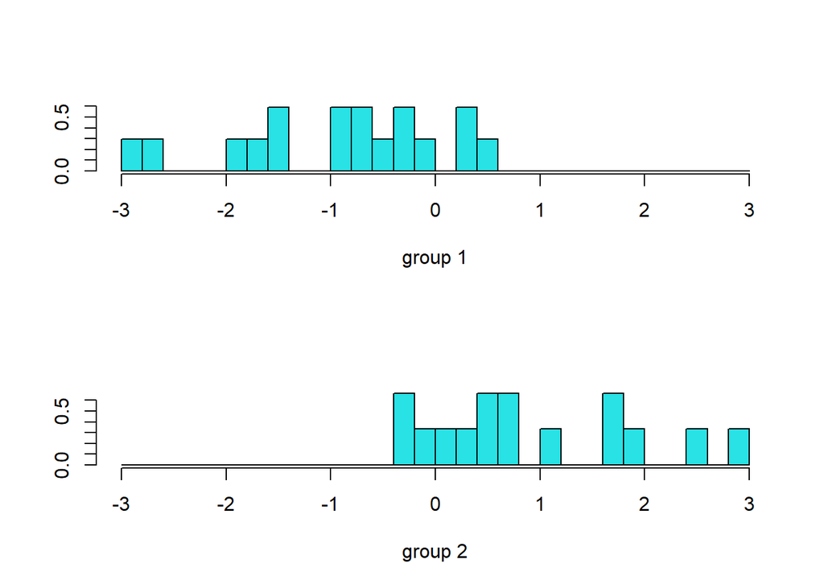

```r
plot(dis)
```

##2.3 Predicci´o de dades noves amb predict()

```r
newdata <- rbind(c(171,140.5,127,69.5,137),c(179,132,140,72,138.5),dis$means)
# important posar els mateixos noms de les variables que al fitxer al qual hem aplicat lda() !
colnames(newdata)<- c("Length", "Breadth", "Height", "Fheight", "Fbreadth")
rownames(newdata)<- c("crani1","crani2","m1","m2")
newdata <- as.data.frame(newdata)
newdata
```

```
##          Length  Breadth   Height  Fheight Fbreadth
## crani1 171.0000 140.5000 127.0000 69.50000 137.0000
## crani2 179.0000 132.0000 140.0000 72.00000 138.5000
## m1     174.8235 139.3529 132.0000 69.82353 130.3529
## m2     185.7333 138.7333 134.7667 76.46667 137.5000
```

```r
predict(dis,newdata=newdata)
```

```
## $class
## [1] 1 2 1 2
## Levels: 1 2
##
## $posterior
##                1         2
## crani1 0.7545066 0.2454934
## crani2 0.1741016 0.8258984
## m1     0.8520437 0.1479563
## m2     0.1479563 0.8520437
##
## $x
##               LD1
## crani1 -0.6000350
## crani2  0.8319908
## m1     -0.9356070
## m2      0.9356070
```

- El ”crani1” es prediu al grup 1 pero t´e un percentatge del 24.5% de ser del grup 2 i el ”crani2” es prediu al grup 2 pero amb un 17.4% de possibilitats de ser del grup 1.
- L’objecte $x cont´e les puntuacions discriminants can`oniques dels dos cranis (els scores d(x) de les noves dades).

#3. Discriminant per m´es de dos grups (k > 2) amb lda()

```r
data(iris)
Iris <- iris
names(Iris)[5] <- "Sp"
Iris$Sp <- as.factor(Iris$Sp)
```

```r
library(car)
```

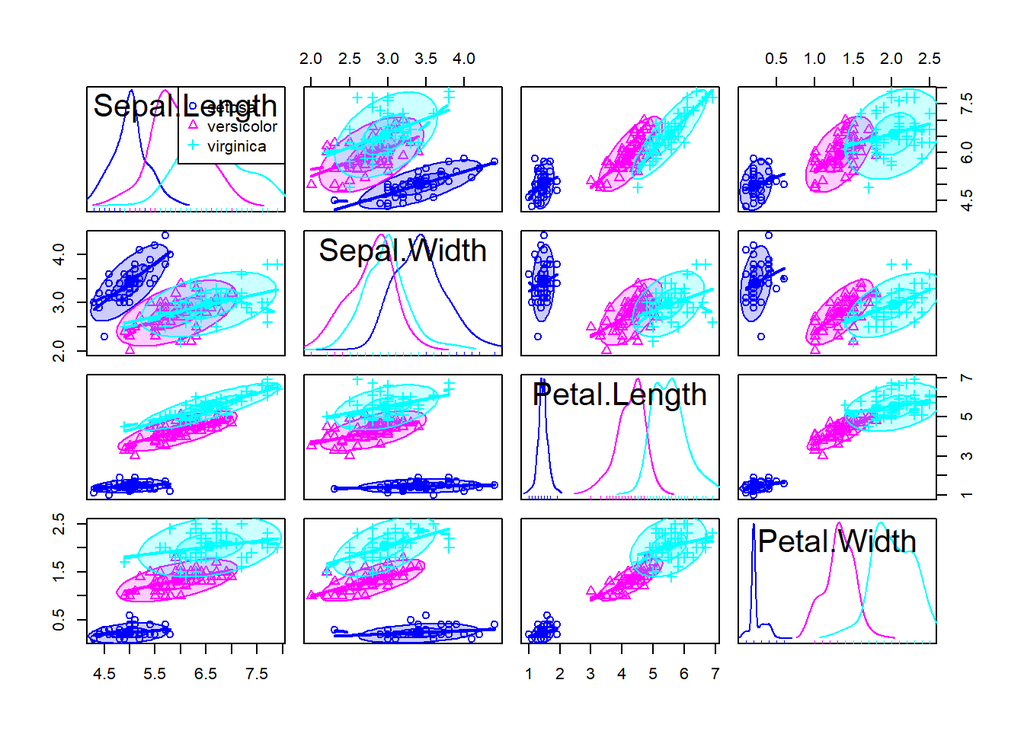

```r
scatterplotMatrix(~ .|Sp, data=Iris, ellipse=T)
```

```r
#library(klaR)
#partimat( Sp ~.,data= Iris, method="lda")
```

##3.2 Previ: Test H0 : µ1 = . . . = µk

```r
fit<- manova(as.matrix(Iris[,1:4])~ as.factor(Iris$Sp))
sfit<- summary(fit)
B<-sfit$SS[[1]] # between groups cov. matrix: entre grups
W<-sfit$SS[[2]] # within groups cov. matrix: dins de grups
sumWilks <- summary(fit, test = "Wilks") # ANOVA table of Wilks' lambda
```

3.3 Discriminant amb lda()

```r
iris.lda <- lda(Sp ~ . , data=Iris) # "Sp ~ ." indica Sp respecte la resta de variables
# coefs. dels vectors que d´onen les puntuacions discriminants
a1 <- iris.lda$scaling[,1] ; a1 # primer vector propi reescalat
```

```
## Sepal.Length  Sepal.Width Petal.Length  Petal.Width
##    0.8293776    1.5344731   -2.2012117   -2.8104603
```

```r
a2 <- iris.lda$scaling[,2] ; a2 # segon vep reescalat
```

```
## Sepal.Length  Sepal.Width Petal.Length  Petal.Width
##  -0.02410215  -2.16452123   0.93192121  -2.83918785
```

```r
iris.cdis <- predict(iris.lda, Iris[1:10, 1:4])
resum <- cbind(iris.cdis$posterior,iris.cdis$x,iris.cdis$class)
colnames(resum) <- c ("post1","post2","post3","dx.1","dx.2","G.pred")
resum <- as.data.frame(resum)
head(resum)
```

```
##   post1        post2        post3     dx.1       dx.2 G.pred
## 1     1 3.896358e-22 2.611168e-42 8.061800 -0.3004206      1
## 2     1 7.217970e-18 5.042143e-37 7.128688  0.7866604      1
## 3     1 1.463849e-19 4.675932e-39 7.489828  0.2653845      1
## 4     1 1.268536e-16 3.566610e-35 6.813201  0.6706311      1
## 5     1 1.637387e-22 1.082605e-42 8.132309 -0.5144625      1
## 6     1 3.883282e-21 4.566540e-40 7.701947 -1.4617210      1
```

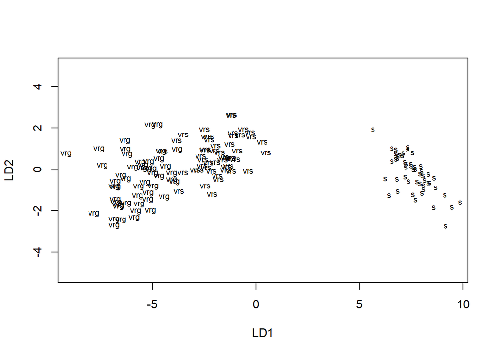

```r
plot(iris.lda, abbrev=T)
```

```r
# ?plot.lda
```